# HW7_Zhou_Xiaoyou

## Analysis of Health Inspections Across Prince George's County

### Data Preparation and Cleansing

Read in the data.

```python
#import the dataset
import pandas as pd
df=pd.read_csv("HW7_Food Inspection.csv")
df.head()
```

|  | Establishment_id | Name | Category | Inspection_date | Inspection_results | City | State | Zip | Address_line_1 | Address_line_2 | ... | Proper_sewage_disposal | No_bare_hand_contact | Adequate_hand_washing_facilities | Rodent_and_insects | Food_contact_surfaces_and_equipment | Inspection_type | Owner | Type | Location | Zip Codes |
| --- | --- | --- | --- | --- | --- | --- | --- | --- | --- | --- | --- | --- | --- | --- | --- | --- | --- | --- | --- | --- | --- |
| 0 | 8176 | LAUREL DUTCH MARKET - SAMMIE'S PRODUCE | Carry-out | 09/05/2019 12:00:00 AM | Critical Violations observed | LAUREL | MD | 20707.0 | 9701 FORT MEADE RD | ------ | ... | In Compliance | In Compliance | In Compliance | In Compliance | In Compliance | Monitoring | Samuel Stoltzfus | Food Establishments | POINT (-76.838165 39.095491) | 15996.0 |
| 1 | 14622 | JERSEY MIKE'S SUBS | Fast Food | 09/06/2019 12:00:00 AM | Critical Violations observed | Riverdale | MD | 20737.0 | 6761 45th ST | ------ | ... | In Compliance | In Compliance | In Compliance | In Compliance | In Compliance | Re-inspection | DANIEL MALAMIS | Food Establishments | NaN | NaN |
| 2 | 7273 | ACCOKEEK ACADEMY | Public School | 09/09/2019 12:00:00 AM | Non-Compliant - Violations Observed | ACCOKEEK | MD | 20607.0 | 14400 BERRY RD | ------ | ... | In Compliance | In Compliance | In Compliance | In Compliance | In Compliance | Comprehensive | MARK FOSSETT | Food Establishments | POINT (-76.980676 38.687531) | 8834.0 |
| 3 | 2103 | PAPA JOHNS 728 | Carry-out | 09/05/2019 12:00:00 AM | Compliant - No Health Risk | BOWIE | MD | 20715.0 | 6852 RACE TRACK RD | ------ | ... | In Compliance | In Compliance | In Compliance | In Compliance | In Compliance | Re-inspection | Annie Berkovicz | Food Establishments | POINT (-76.729269 38.983881) | 16435.0 |
| 4 | 347 | COLUMBIA PARK ELEMENTARY SCHOOL | Public School | 09/05/2019 12:00:00 AM | Critical Violations observed | LANDOVER | MD | 20785.0 | 1901 KENT VILLAGE DR | ------ | ... | In Compliance | In Compliance | In Compliance | Out of Compliance | In Compliance | Comprehensive | MARK FOSSETT | Food Establishments | POINT (-76.88767 38.91584) | 31451.0 |

5 rows × 30 columns

Take a look at the table of the unique values of Category

```python
#get the unique values of Category
df['Category'].value_counts()
```

```
Carry-out                      7063
Fast Food                      5456
Full Service                   4910
Public School                  3700
Convenience Store              2223
Grocery Store                  1900
Restaurant                     1348
Stadium/Amusement Park          763
College/University              717
Gas Station Store               687
Health Care Facility            601
Hotel                           378
Bakery                          362
Snack Bar/Concession Stand      318
Church/Temple/Mosque            303
Dollar Store                    277
Coffee Shop                     268
Catering Only                   267
Bar/Tavern/Lounge               261
Fast Food - Chain               259
Private School                  254
Ice Cream                       192
Casino                          149
Senior Nutrition Program        142
Private Club                    140
Fire/Community Hall             106
Seafood                          87
Group Home                       83
Fast Food - Local                82
Meat/Poultry Market              79
Buffet                           75
Deli                             74
After School Supper Program      69
Membership Warehouse             66
Bakery/Catering                  56
Pizza                            51
Cafeteria                        38
Limited Service                  31
Institution                      29
Night Club                       26
Pre-Packaged Only                25
Excluded                         24
Grocery Store- Medium            24
Grocery Store - Large            23
Full Service/Catering            14
Diner                            12
Banquet Hall/Ballroom            11
Multiple Facilities              10
Specialty Store                  10
Donut                             8
@Full Service                     5
Diet/Nutrition Site               4
Micro Market                      3
Farmer's Market                   2
B & B                             1
Delivery Only                     1
School                            1
Name: Category, dtype: int64
```

Which values do you believe represent a restaurant?

Values such as 'Carry-out','Fast Food','Full Service','Bakery/Catering','Restaurant','Catering Only', 'Cafeteria', 'Snack Bar/Concession Stand', 'Pre-Packaged Only', 'Deli','Seafood','Fast Food - Chain', 'Full Service/Catering','Buffet','Pizza','Fast Food - Local','Delivery Only', '@Full Service', 'Diner' are considered restaurant.

Create a single dummy variable for restaurant that combines multiple values from Category.

```python
#Create a single dummy variable for restaurant that combines multiple values from Category.
import numpy as np
restaurant=[ 'Carry-out','Fast Food','Full Service','Bakery/Catering','Restaurant','Catering Only', 'Cafeteria', 'Snack Bar/Concession Stand', 'Pre-Packaged Only', 'Deli','Seafood','Fast Food - Chain', 'Full Service/Catering','Buffet','Pizza','Fast Food - Local','Delivery Only', '@Full Service', 'Diner']
df['Restaurant_or_not']=np.where(df['Category'].isin(restaurant),1,0)
df.head()
```

|  | Establishment_id | Name | Category | Inspection_date | Inspection_results | City | State | Zip | Address_line_1 | Address_line_2 | ... | No_bare_hand_contact | Adequate_hand_washing_facilities | Rodent_and_insects | Food_contact_surfaces_and_equipment | Inspection_type | Owner | Type | Location | Zip Codes | Restaurant_or_not |
| --- | --- | --- | --- | --- | --- | --- | --- | --- | --- | --- | --- | --- | --- | --- | --- | --- | --- | --- | --- | --- | --- |
| 0 | 8176 | LAUREL DUTCH MARKET - SAMMIE'S PRODUCE | Carry-out | 09/05/2019 12:00:00 AM | Critical Violations observed | LAUREL | MD | 20707.0 | 9701 FORT MEADE RD | ------ | ... | In Compliance | In Compliance | In Compliance | In Compliance | Monitoring | Samuel Stoltzfus | Food Establishments | POINT (-76.838165 39.095491) | 15996.0 | 1 |
| 1 | 14622 | JERSEY MIKE'S SUBS | Fast Food | 09/06/2019 12:00:00 AM | Critical Violations observed | Riverdale | MD | 20737.0 | 6761 45th ST | ------ | ... | In Compliance | In Compliance | In Compliance | In Compliance | Re-inspection | DANIEL MALAMIS | Food Establishments | NaN | NaN | 1 |
| 2 | 7273 | ACCOKEEK ACADEMY | Public School | 09/09/2019 12:00:00 AM | Non-Compliant - Violations Observed | ACCOKEEK | MD | 20607.0 | 14400 BERRY RD | ------ | ... | In Compliance | In Compliance | In Compliance | In Compliance | Comprehensive | MARK FOSSETT | Food Establishments | POINT (-76.980676 38.687531) | 8834.0 | 0 |
| 3 | 2103 | PAPA JOHNS 728 | Carry-out | 09/05/2019 12:00:00 AM | Compliant - No Health Risk | BOWIE | MD | 20715.0 | 6852 RACE TRACK RD | ------ | ... | In Compliance | In Compliance | In Compliance | In Compliance | Re-inspection | Annie Berkovicz | Food Establishments | POINT (-76.729269 38.983881) | 16435.0 | 1 |
| 4 | 347 | COLUMBIA PARK ELEMENTARY SCHOOL | Public School | 09/05/2019 12:00:00 AM | Critical Violations observed | LANDOVER | MD | 20785.0 | 1901 KENT VILLAGE DR | ------ | ... | In Compliance | In Compliance | Out of Compliance | In Compliance | Comprehensive | MARK FOSSETT | Food Establishments | POINT (-76.88767 38.91584) | 31451.0 | 0 |

5 rows × 31 columns

Convert the Inspection_date column into a datetime column and create new date columns.

```python
 #Convert the Inspection_date column into a datetime column.
import datetime as dt
%timeit pd.to_datetime(df['Inspection_date'], infer_datetime_format=True)
```

```
5.89 s ± 1.13 s per loop (mean ± std. dev. of 7 runs, 1 loop each)
```

```python
#Create a new column for the year of the inspection.
df['Year'] = pd.DatetimeIndex(df['Inspection_date']).year
df.head()
```

|  | Establishment_id | Name | Category | Inspection_date | Inspection_results | City | State | Zip | Address_line_1 | Address_line_2 | ... | Adequate_hand_washing_facilities | Rodent_and_insects | Food_contact_surfaces_and_equipment | Inspection_type | Owner | Type | Location | Zip Codes | Restaurant_or_not | Year |
| --- | --- | --- | --- | --- | --- | --- | --- | --- | --- | --- | --- | --- | --- | --- | --- | --- | --- | --- | --- | --- | --- |
| 0 | 8176 | LAUREL DUTCH MARKET - SAMMIE'S PRODUCE | Carry-out | 09/05/2019 12:00:00 AM | Critical Violations observed | LAUREL | MD | 20707.0 | 9701 FORT MEADE RD | ------ | ... | In Compliance | In Compliance | In Compliance | Monitoring | Samuel Stoltzfus | Food Establishments | POINT (-76.838165 39.095491) | 15996.0 | 1 | 2019 |
| 1 | 14622 | JERSEY MIKE'S SUBS | Fast Food | 09/06/2019 12:00:00 AM | Critical Violations observed | Riverdale | MD | 20737.0 | 6761 45th ST | ------ | ... | In Compliance | In Compliance | In Compliance | Re-inspection | DANIEL MALAMIS | Food Establishments | NaN | NaN | 1 | 2019 |
| 2 | 7273 | ACCOKEEK ACADEMY | Public School | 09/09/2019 12:00:00 AM | Non-Compliant - Violations Observed | ACCOKEEK | MD | 20607.0 | 14400 BERRY RD | ------ | ... | In Compliance | In Compliance | In Compliance | Comprehensive | MARK FOSSETT | Food Establishments | POINT (-76.980676 38.687531) | 8834.0 | 0 | 2019 |
| 3 | 2103 | PAPA JOHNS 728 | Carry-out | 09/05/2019 12:00:00 AM | Compliant - No Health Risk | BOWIE | MD | 20715.0 | 6852 RACE TRACK RD | ------ | ... | In Compliance | In Compliance | In Compliance | Re-inspection | Annie Berkovicz | Food Establishments | POINT (-76.729269 38.983881) | 16435.0 | 1 | 2019 |
| 4 | 347 | COLUMBIA PARK ELEMENTARY SCHOOL | Public School | 09/05/2019 12:00:00 AM | Critical Violations observed | LANDOVER | MD | 20785.0 | 1901 KENT VILLAGE DR | ------ | ... | In Compliance | Out of Compliance | In Compliance | Comprehensive | MARK FOSSETT | Food Establishments | POINT (-76.88767 38.91584) | 31451.0 | 0 | 2019 |

5 rows × 32 columns

```python
#Create a new column for the month of the inspection.
df['Month'] = pd.DatetimeIndex(df['Inspection_date']).month
df.head()
```

|  | Establishment_id | Name | Category | Inspection_date | Inspection_results | City | State | Zip | Address_line_1 | Address_line_2 | ... | Rodent_and_insects | Food_contact_surfaces_and_equipment | Inspection_type | Owner | Type | Location | Zip Codes | Restaurant_or_not | Year | Month |
| --- | --- | --- | --- | --- | --- | --- | --- | --- | --- | --- | --- | --- | --- | --- | --- | --- | --- | --- | --- | --- | --- |
| 0 | 8176 | LAUREL DUTCH MARKET - SAMMIE'S PRODUCE | Carry-out | 09/05/2019 12:00:00 AM | Critical Violations observed | LAUREL | MD | 20707.0 | 9701 FORT MEADE RD | ------ | ... | In Compliance | In Compliance | Monitoring | Samuel Stoltzfus | Food Establishments | POINT (-76.838165 39.095491) | 15996.0 | 1 | 2019 | 9 |
| 1 | 14622 | JERSEY MIKE'S SUBS | Fast Food | 09/06/2019 12:00:00 AM | Critical Violations observed | Riverdale | MD | 20737.0 | 6761 45th ST | ------ | ... | In Compliance | In Compliance | Re-inspection | DANIEL MALAMIS | Food Establishments | NaN | NaN | 1 | 2019 | 9 |
| 2 | 7273 | ACCOKEEK ACADEMY | Public School | 09/09/2019 12:00:00 AM | Non-Compliant - Violations Observed | ACCOKEEK | MD | 20607.0 | 14400 BERRY RD | ------ | ... | In Compliance | In Compliance | Comprehensive | MARK FOSSETT | Food Establishments | POINT (-76.980676 38.687531) | 8834.0 | 0 | 2019 | 9 |
| 3 | 2103 | PAPA JOHNS 728 | Carry-out | 09/05/2019 12:00:00 AM | Compliant - No Health Risk | BOWIE | MD | 20715.0 | 6852 RACE TRACK RD | ------ | ... | In Compliance | In Compliance | Re-inspection | Annie Berkovicz | Food Establishments | POINT (-76.729269 38.983881) | 16435.0 | 1 | 2019 | 9 |
| 4 | 347 | COLUMBIA PARK ELEMENTARY SCHOOL | Public School | 09/05/2019 12:00:00 AM | Critical Violations observed | LANDOVER | MD | 20785.0 | 1901 KENT VILLAGE DR | ------ | ... | Out of Compliance | In Compliance | Comprehensive | MARK FOSSETT | Food Establishments | POINT (-76.88767 38.91584) | 31451.0 | 0 | 2019 | 9 |

5 rows × 33 columns

```python
#Create a column for the year and month.
df['Month_Year'] = pd.to_datetime(df['Inspection_date']).dt.to_period('M')
df.head()
```

|  | Establishment_id | Name | Category | Inspection_date | Inspection_results | City | State | Zip | Address_line_1 | Address_line_2 | ... | Food_contact_surfaces_and_equipment | Inspection_type | Owner | Type | Location | Zip Codes | Restaurant_or_not | Year | Month | Month_Year |
| --- | --- | --- | --- | --- | --- | --- | --- | --- | --- | --- | --- | --- | --- | --- | --- | --- | --- | --- | --- | --- | --- |
| 0 | 8176 | LAUREL DUTCH MARKET - SAMMIE'S PRODUCE | Carry-out | 09/05/2019 12:00:00 AM | Critical Violations observed | LAUREL | MD | 20707.0 | 9701 FORT MEADE RD | ------ | ... | In Compliance | Monitoring | Samuel Stoltzfus | Food Establishments | POINT (-76.838165 39.095491) | 15996.0 | 1 | 2019 | 9 | 2019-09 |
| 1 | 14622 | JERSEY MIKE'S SUBS | Fast Food | 09/06/2019 12:00:00 AM | Critical Violations observed | Riverdale | MD | 20737.0 | 6761 45th ST | ------ | ... | In Compliance | Re-inspection | DANIEL MALAMIS | Food Establishments | NaN | NaN | 1 | 2019 | 9 | 2019-09 |
| 2 | 7273 | ACCOKEEK ACADEMY | Public School | 09/09/2019 12:00:00 AM | Non-Compliant - Violations Observed | ACCOKEEK | MD | 20607.0 | 14400 BERRY RD | ------ | ... | In Compliance | Comprehensive | MARK FOSSETT | Food Establishments | POINT (-76.980676 38.687531) | 8834.0 | 0 | 2019 | 9 | 2019-09 |
| 3 | 2103 | PAPA JOHNS 728 | Carry-out | 09/05/2019 12:00:00 AM | Compliant - No Health Risk | BOWIE | MD | 20715.0 | 6852 RACE TRACK RD | ------ | ... | In Compliance | Re-inspection | Annie Berkovicz | Food Establishments | POINT (-76.729269 38.983881) | 16435.0 | 1 | 2019 | 9 | 2019-09 |
| 4 | 347 | COLUMBIA PARK ELEMENTARY SCHOOL | Public School | 09/05/2019 12:00:00 AM | Critical Violations observed | LANDOVER | MD | 20785.0 | 1901 KENT VILLAGE DR | ------ | ... | In Compliance | Comprehensive | MARK FOSSETT | Food Establishments | POINT (-76.88767 38.91584) | 31451.0 | 0 | 2019 | 9 | 2019-09 |

5 rows × 34 columns

For each column with the type of compliance, e.g. "Rodent and Insects," create a dummy variable that is 1 if the establishment is out of compliance and 0 otherwise.

```python
#find out columns with the type of compliance
df3=df[df.isin(["In Compliance"])|df.isin(["Out of Compliance"])].dropna(how='all',axis=1)
df3.head()
```

|  | Food_from_approved_source | Food_protected_from_contamination | Ill_workers_restricted | Proper_hand_washing | Cooling_time_and_temperature | Cold_holding_temperature | Hot_holding_temperature | Cooking_time_and_temperature | Reheating_time_and_temperature | Hot_and_cold_running_water_provided | Proper_sewage_disposal | No_bare_hand_contact | Adequate_hand_washing_facilities | Rodent_and_insects | Food_contact_surfaces_and_equipment |
| --- | --- | --- | --- | --- | --- | --- | --- | --- | --- | --- | --- | --- | --- | --- | --- |
| 0 | In Compliance | Out of Compliance | In Compliance | In Compliance | In Compliance | In Compliance | In Compliance | In Compliance | In Compliance | In Compliance | In Compliance | In Compliance | In Compliance | In Compliance | In Compliance |
| 1 | In Compliance | In Compliance | In Compliance | In Compliance | In Compliance | Out of Compliance | In Compliance | In Compliance | In Compliance | In Compliance | In Compliance | In Compliance | In Compliance | In Compliance | In Compliance |
| 2 | In Compliance | In Compliance | In Compliance | In Compliance | In Compliance | In Compliance | In Compliance | In Compliance | In Compliance | In Compliance | In Compliance | In Compliance | In Compliance | In Compliance | In Compliance |
| 3 | In Compliance | In Compliance | In Compliance | In Compliance | In Compliance | In Compliance | In Compliance | In Compliance | In Compliance | In Compliance | In Compliance | In Compliance | In Compliance | In Compliance | In Compliance |
| 4 | In Compliance | In Compliance | In Compliance | In Compliance | In Compliance | Out of Compliance | In Compliance | In Compliance | In Compliance | In Compliance | In Compliance | In Compliance | In Compliance | Out of Compliance | In Compliance |

```python
# list all columns with the type of compliance
columns=list(df3.columns)
columns
```

```
['Food_from_approved_source',
 'Food_protected_from_contamination',
 'Ill_workers_restricted',
 'Proper_hand_washing',
 'Cooling_time_and_temperature',
 'Cold_holding_temperature',
 'Hot_holding_temperature',
 'Cooking_time_and_temperature',
 'Reheating_time_and_temperature',
 'Hot_and_cold_running_water_provided',
 'Proper_sewage_disposal',
 'No_bare_hand_contact',
 'Adequate_hand_washing_facilities',
 'Rodent_and_insects',
 'Food_contact_surfaces_and_equipment']
```

```python
#check whether columns have null values
df3.isnull().sum()
```

```
Food_from_approved_source              0
Food_protected_from_contamination      0
Ill_workers_restricted                 0
Proper_hand_washing                    0
Cooling_time_and_temperature           0
Cold_holding_temperature               0
Hot_holding_temperature                0
Cooking_time_and_temperature           0
Reheating_time_and_temperature         0
Hot_and_cold_running_water_provided    0
Proper_sewage_disposal                 0
No_bare_hand_contact                   0
Adequate_hand_washing_facilities       0
Rodent_and_insects                     0
Food_contact_surfaces_and_equipment    0
dtype: int64
```

From the result we see no column with the type of compliance contains null values

```python
#change the values of each raw to dummies
for col in columns:
    df[col]=df[col].astype(str)
    df[col].replace("In Compliance",0,inplace=True)
    df[col].replace("Out of Compliance",1,inplace=True)
```

```python
df[columns].head()
```

|  | Food_from_approved_source | Food_protected_from_contamination | Ill_workers_restricted | Proper_hand_washing | Cooling_time_and_temperature | Cold_holding_temperature | Hot_holding_temperature | Cooking_time_and_temperature | Reheating_time_and_temperature | Hot_and_cold_running_water_provided | Proper_sewage_disposal | No_bare_hand_contact | Adequate_hand_washing_facilities | Rodent_and_insects | Food_contact_surfaces_and_equipment |
| --- | --- | --- | --- | --- | --- | --- | --- | --- | --- | --- | --- | --- | --- | --- | --- |
| 0 | 0 | 1 | 0 | 0 | 0 | 0 | 0 | 0 | 0 | 0 | 0 | 0 | 0 | 0 | 0 |
| 1 | 0 | 0 | 0 | 0 | 0 | 1 | 0 | 0 | 0 | 0 | 0 | 0 | 0 | 0 | 0 |
| 2 | 0 | 0 | 0 | 0 | 0 | 0 | 0 | 0 | 0 | 0 | 0 | 0 | 0 | 0 | 0 |
| 3 | 0 | 0 | 0 | 0 | 0 | 0 | 0 | 0 | 0 | 0 | 0 | 0 | 0 | 0 | 0 |
| 4 | 0 | 0 | 0 | 0 | 0 | 1 | 0 | 0 | 0 | 0 | 0 | 0 | 0 | 1 | 0 |

Create a new column that contains the number of violations for that inspection (the number of categories where the establishment was not in compliance).

```python
#sum all the values in columns
df["Violation_counts"]=df[columns].astype(int).sum(axis=1)
df.head()
```

|  | Establishment_id | Name | Category | Inspection_date | Inspection_results | City | State | Zip | Address_line_1 | Address_line_2 | ... | Inspection_type | Owner | Type | Location | Zip Codes | Restaurant_or_not | Year | Month | Month_Year | Violation_counts |
| --- | --- | --- | --- | --- | --- | --- | --- | --- | --- | --- | --- | --- | --- | --- | --- | --- | --- | --- | --- | --- | --- |
| 0 | 8176 | LAUREL DUTCH MARKET - SAMMIE'S PRODUCE | Carry-out | 09/05/2019 12:00:00 AM | Critical Violations observed | LAUREL | MD | 20707.0 | 9701 FORT MEADE RD | ------ | ... | Monitoring | Samuel Stoltzfus | Food Establishments | POINT (-76.838165 39.095491) | 15996.0 | 1 | 2019 | 9 | 2019-09 | 1 |
| 1 | 14622 | JERSEY MIKE'S SUBS | Fast Food | 09/06/2019 12:00:00 AM | Critical Violations observed | Riverdale | MD | 20737.0 | 6761 45th ST | ------ | ... | Re-inspection | DANIEL MALAMIS | Food Establishments | NaN | NaN | 1 | 2019 | 9 | 2019-09 | 1 |
| 2 | 7273 | ACCOKEEK ACADEMY | Public School | 09/09/2019 12:00:00 AM | Non-Compliant - Violations Observed | ACCOKEEK | MD | 20607.0 | 14400 BERRY RD | ------ | ... | Comprehensive | MARK FOSSETT | Food Establishments | POINT (-76.980676 38.687531) | 8834.0 | 0 | 2019 | 9 | 2019-09 | 0 |
| 3 | 2103 | PAPA JOHNS 728 | Carry-out | 09/05/2019 12:00:00 AM | Compliant - No Health Risk | BOWIE | MD | 20715.0 | 6852 RACE TRACK RD | ------ | ... | Re-inspection | Annie Berkovicz | Food Establishments | POINT (-76.729269 38.983881) | 16435.0 | 1 | 2019 | 9 | 2019-09 | 0 |
| 4 | 347 | COLUMBIA PARK ELEMENTARY SCHOOL | Public School | 09/05/2019 12:00:00 AM | Critical Violations observed | LANDOVER | MD | 20785.0 | 1901 KENT VILLAGE DR | ------ | ... | Comprehensive | MARK FOSSETT | Food Establishments | POINT (-76.88767 38.91584) | 31451.0 | 0 | 2019 | 9 | 2019-09 | 2 |

5 rows × 35 columns

Create a dummy variable that is 1 if the establishment is out of compliance in any category.

```python
#Create a dummy variable
df["Compliance_or_not"]=np.where(df['Violation_counts']==0,0,1)
df.head()
```

|  | Establishment_id | Name | Category | Inspection_date | Inspection_results | City | State | Zip | Address_line_1 | Address_line_2 | ... | Owner | Type | Location | Zip Codes | Restaurant_or_not | Year | Month | Month_Year | Violation_counts | Compliance_or_not |
| --- | --- | --- | --- | --- | --- | --- | --- | --- | --- | --- | --- | --- | --- | --- | --- | --- | --- | --- | --- | --- | --- |
| 0 | 8176 | LAUREL DUTCH MARKET - SAMMIE'S PRODUCE | Carry-out | 09/05/2019 12:00:00 AM | Critical Violations observed | LAUREL | MD | 20707.0 | 9701 FORT MEADE RD | ------ | ... | Samuel Stoltzfus | Food Establishments | POINT (-76.838165 39.095491) | 15996.0 | 1 | 2019 | 9 | 2019-09 | 1 | 1 |
| 1 | 14622 | JERSEY MIKE'S SUBS | Fast Food | 09/06/2019 12:00:00 AM | Critical Violations observed | Riverdale | MD | 20737.0 | 6761 45th ST | ------ | ... | DANIEL MALAMIS | Food Establishments | NaN | NaN | 1 | 2019 | 9 | 2019-09 | 1 | 1 |
| 2 | 7273 | ACCOKEEK ACADEMY | Public School | 09/09/2019 12:00:00 AM | Non-Compliant - Violations Observed | ACCOKEEK | MD | 20607.0 | 14400 BERRY RD | ------ | ... | MARK FOSSETT | Food Establishments | POINT (-76.980676 38.687531) | 8834.0 | 0 | 2019 | 9 | 2019-09 | 0 | 0 |
| 3 | 2103 | PAPA JOHNS 728 | Carry-out | 09/05/2019 12:00:00 AM | Compliant - No Health Risk | BOWIE | MD | 20715.0 | 6852 RACE TRACK RD | ------ | ... | Annie Berkovicz | Food Establishments | POINT (-76.729269 38.983881) | 16435.0 | 1 | 2019 | 9 | 2019-09 | 0 | 0 |
| 4 | 347 | COLUMBIA PARK ELEMENTARY SCHOOL | Public School | 09/05/2019 12:00:00 AM | Critical Violations observed | LANDOVER | MD | 20785.0 | 1901 KENT VILLAGE DR | ------ | ... | MARK FOSSETT | Food Establishments | POINT (-76.88767 38.91584) | 31451.0 | 0 | 2019 | 9 | 2019-09 | 2 | 1 |

5 rows × 36 columns

For establishments with multiple inspections, create a new DataFrame in wide format. Keep only the establishment ID, Category, Inspection_date, and number of violations.

```python
#create a new DataFrame in wide format
newdf=df[['Establishment_id', 'Category', 'Inspection_date','Violation_counts']]
newdf.head()
```

|  | Establishment_id | Category | Inspection_date | Violation_counts |
| --- | --- | --- | --- | --- |
| 0 | 8176 | Carry-out | 09/05/2019 12:00:00 AM | 1 |
| 1 | 14622 | Fast Food | 09/06/2019 12:00:00 AM | 1 |
| 2 | 7273 | Public School | 09/09/2019 12:00:00 AM | 0 |
| 3 | 2103 | Carry-out | 09/05/2019 12:00:00 AM | 0 |
| 4 | 347 | Public School | 09/05/2019 12:00:00 AM | 2 |

Make sure category is consistent within ID and resolve any discrepancies if necessary (i.e. each establishment has only one category).

```python
#find the unique values of 'Establishment_id'
id=newdf['Establishment_id'].unique()
id=pd.Series(id)
```

```python
#find 'Establishment_id' which has more than 1 category
uid=[]
for i in id:
    counts=np.count_nonzero(newdf[newdf['Establishment_id']==i]['Category'].unique())
    if counts>1:
        uid.append(i)
uid=pd.Series(uid)
```

```python
#resolve any discrepancies
#only leave the first category for each 'Establishment_id' that has more than 1 category
df4=pd.DataFrame()
for u in uid:
    choose=newdf[newdf['Establishment_id']==u]['Category'].unique()[0]
    value=newdf[newdf['Establishment_id']==u][newdf['Category']==choose]
    df4=df4.append(value,ignore_index=True)
df4.head()
```

|  | Establishment_id | Category | Inspection_date | Violation_counts |
| --- | --- | --- | --- | --- |
| 0 | 14622 | Fast Food | 09/06/2019 12:00:00 AM | 1 |
| 1 | 14622 | Fast Food | 09/04/2019 12:00:00 AM | 1 |
| 2 | 14622 | Fast Food | 09/04/2019 12:00:00 AM | 1 |
| 3 | 13553 | Fast Food | 09/09/2019 12:00:00 AM | 1 |
| 4 | 439 | Carry-out | 09/05/2019 12:00:00 AM | 2 |

```python
#create a dataframe whose 'Establishment_id' only has no more than 1 category
df5=pd.DataFrame()
for o in id:
    if o not in uid:
        value2=newdf[newdf['Establishment_id']==o]
        df5=df5.append(value2,ignore_index=True)
df5.head()
```

|  | Establishment_id | Category | Inspection_date | Violation_counts |
| --- | --- | --- | --- | --- |
| 0 | 8176 | Carry-out | 09/05/2019 12:00:00 AM | 1 |
| 1 | 8176 | Carry-out | 10/13/2016 12:00:00 AM | 0 |
| 2 | 8176 | Carry-out | 09/08/2017 12:00:00 AM | 1 |
| 3 | 8176 | Carry-out | 07/29/2016 12:00:00 AM | 0 |
| 4 | 8176 | Carry-out | 10/26/2018 12:00:00 AM | 0 |

```python
#contanete two dataframes
#this is a dataframe whose category is consistent within ID
newnewdf= pd.concat([df4, df5], axis=0,ignore_index=True)
newnewdf.sort_values(by='Establishment_id').head()
```

|  | Establishment_id | Category | Inspection_date | Violation_counts |
| --- | --- | --- | --- | --- |
| 2050 | 2 | Fast Food - Chain | 02/07/2020 12:00:00 AM | 0 |
| 2049 | 2 | Fast Food - Chain | 01/10/2020 12:00:00 AM | 0 |
| 966 | 4 | Restaurant | 03/11/2020 12:00:00 AM | 1 |
| 965 | 4 | Restaurant | 10/31/2019 12:00:00 AM | 1 |
| 322 | 10 | Limited Service | 06/10/2016 12:00:00 AM | 0 |

Reshape from long to wide (pivot) such that each establishment is a row and you have a column for the date and number of violations for inspection 1, inspection 2, inspection 3, etc.

```python
tables=newdf.pivot_table(values='Violation_counts',index=['Establishment_id','Inspection_date'],aggfunc='sum',margins=True)
tables
```

| Establishment_id | Inspection_date | Violation_counts |
| --- | --- | --- |
| 1 | 01/02/2013 12:00:00 AM | 0 |
|  | 02/06/2017 12:00:00 AM | 0 |
|  | 02/13/2012 12:00:00 AM | 0 |
|  | 03/10/2016 12:00:00 AM | 0 |
|  | 05/31/2013 12:00:00 AM | 0 |
|  | 06/17/2014 12:00:00 AM | 0 |
|  | 06/24/2016 12:00:00 AM | 0 |
|  | 08/13/2015 12:00:00 AM | 1 |
|  | 08/22/2013 12:00:00 AM | 2 |
|  | 09/22/2014 12:00:00 AM | 2 |
|  | 09/27/2017 12:00:00 AM | 0 |
|  | 10/02/2012 12:00:00 AM | 0 |
|  | 10/24/2016 12:00:00 AM | 0 |
|  | 10/31/2018 12:00:00 AM | 0 |
|  | 11/08/2019 12:00:00 AM | 0 |
|  | 11/26/2019 12:00:00 AM | 1 |
|  | 12/07/2015 12:00:00 AM | 1 |
|  | 12/29/2014 12:00:00 AM | 1 |
| 2 | 01/10/2020 12:00:00 AM | 0 |
|  | 01/26/2015 12:00:00 AM | 1 |
|  | 01/28/2016 12:00:00 AM | 1 |
|  | 01/29/2016 12:00:00 AM | 0 |
|  | 02/07/2020 12:00:00 AM | 0 |
|  | 02/08/2017 12:00:00 AM | 2 |
|  | 04/15/2014 12:00:00 AM | 0 |
|  | 05/18/2015 12:00:00 AM | 0 |
|  | 06/10/2016 12:00:00 AM | 0 |
|  | 06/27/2017 12:00:00 AM | 0 |
|  | 07/01/2019 12:00:00 AM | 2 |
|  | 07/19/2011 12:00:00 AM | 2 |
| ... | ... | ... |
| 15896 | 10/15/2019 12:00:00 AM | 0 |
| 15899 | 02/14/2020 12:00:00 AM | 0 |
| 15904 | 03/06/2020 12:00:00 AM | 1 |
| 15908 | 03/05/2020 12:00:00 AM | 0 |
|  | 10/28/2019 12:00:00 AM | 1 |
| 15910 | 02/21/2020 12:00:00 AM | 0 |
| 15915 | 01/10/2020 12:00:00 AM | 2 |
| 15923 | 11/01/2019 12:00:00 AM | 0 |
| 15959 | 03/05/2020 12:00:00 AM | 0 |
|  | 03/09/2020 12:00:00 AM | 0 |
| 15965 | 02/14/2020 12:00:00 AM | 0 |
| 15973 | 01/02/2020 12:00:00 AM | 0 |
| 15980 | 01/10/2020 12:00:00 AM | 0 |
| 15982 | 01/15/2020 12:00:00 AM | 0 |
| 15984 | 01/24/2020 12:00:00 AM | 0 |
|  | 07/09/2014 12:00:00 AM | 1 |
| 15986 | 01/21/2020 12:00:00 AM | 0 |
| 15992 | 01/15/2020 12:00:00 AM | 0 |
|  | 01/24/2020 12:00:00 AM | 0 |
| 15995 | 01/28/2020 12:00:00 AM | 0 |
| 16007 | 02/11/2020 12:00:00 AM | 0 |
|  | 02/14/2020 12:00:00 AM | 0 |
| 16018 | 02/18/2020 12:00:00 AM | 0 |
|  | 02/20/2020 12:00:00 AM | 0 |
| 16019 | 02/07/2020 12:00:00 AM | 0 |
|  | 02/18/2020 12:00:00 AM | 0 |
| 16056 | 03/02/2020 12:00:00 AM | 0 |
|  | 03/05/2020 12:00:00 AM | 0 |
|  | 03/11/2020 12:00:00 AM | 0 |
| All |  | 25700 |

32045 rows × 1 columns

## Statistics/Data Grouping

What is the most common type of violation? The compliance categories are not mutually exclusive because one restaurant can have multiple violations. Create a table with the number of violations by violation type. Sort the table from the most common to least common violations.

```python
#count the umber of violations by violation type
dfc=df[columns]
counts=dfc[dfc == 1].sum(axis=0).sort_values(ascending=False)
counts
```

```
Cold_holding_temperature               6725.0
Food_contact_surfaces_and_equipment    6044.0
Rodent_and_insects                     5816.0
Hot_holding_temperature                3435.0
Food_protected_from_contamination      1368.0
Proper_hand_washing                    1248.0
Cooling_time_and_temperature            338.0
Hot_and_cold_running_water_provided     229.0
Cooking_time_and_temperature            157.0
Reheating_time_and_temperature          138.0
Food_from_approved_source               103.0
Proper_sewage_disposal                   80.0
Ill_workers_restricted                   19.0
Adequate_hand_washing_facilities          0.0
No_bare_hand_contact                      0.0
dtype: float64
```

The most common type of violation is Cold_holding_temperature.

## Data Visualization

Limit the analysis to restaurants using the dummy variable indicator created previously.

Create a bar graph showing the results of violations from Step 2a.

```python
#create a dataframe that only contain restaurants
dfr=df[df['Restaurant_or_not']==1]
#count the umber of violations by violation type for every restaurant
dfrr=dfr[columns]
countsr=dfrr[dfrr == 1].sum(axis=0).sort_values(ascending=False)
countsr
```

```
Cold_holding_temperature               4585.0
Food_contact_surfaces_and_equipment    4213.0
Rodent_and_insects                     3428.0
Hot_holding_temperature                2058.0
Proper_hand_washing                     936.0
Food_protected_from_contamination       922.0
Cooling_time_and_temperature            258.0
Hot_and_cold_running_water_provided     134.0
Cooking_time_and_temperature            102.0
Reheating_time_and_temperature           98.0
Proper_sewage_disposal                   54.0
Food_from_approved_source                47.0
Ill_workers_restricted                   13.0
Adequate_hand_washing_facilities          0.0
No_bare_hand_contact                      0.0
dtype: float64
```

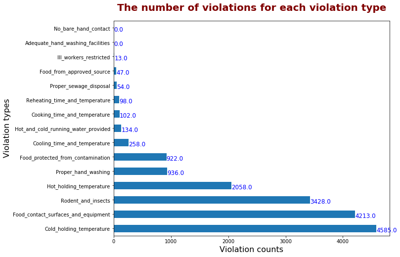

```python
#plot the bar graph
import seaborn as sns

ax = countsr.plot(kind='barh', rot=0,figsize=(10,8))
ax.set_title("The number of violations for each violation type",fontdict={'fontsize': 20, 'fontweight': 700, 'color': 'maroon'}, pad=20)
ax.set_xlabel("Violation counts", fontsize=16)
ax.set_ylabel("Violation types", fontsize=16);

# set individual bar lables
for i in ax.patches:
    ax.text(i.get_width(), i.get_y(), \
            str(round((i.get_width()))), fontsize=12, color='blue')
```

Create a line graph that shows the percent of restaurant inspections that have at least one violation by month and year.

```python
#find all restaurant inspections that have at least one violation
df10=dfr[dfr["Violation_counts"]!=0]
```

```python
#calculate the frequencies
grouped=df10.groupby(by='Year')["Violation_counts"].agg('count')
grouped2=dfr.groupby(by='Year')["Violation_counts"].agg('count')
frequency=grouped/grouped2
frequency
```

```
Year
2011    0.410526
2012    0.353769
2013    0.344344
2014    0.420091
2015    0.504277
2016    0.519097
2017    0.523081
2018    0.492330
2019    0.497108
2020    0.464935
2022         NaN
Name: Violation_counts, dtype: float64
```

```python
year=pd.Series(range(2011,2023,1))
```

```
 <a list of 12 Text xticklabel objects>)
```

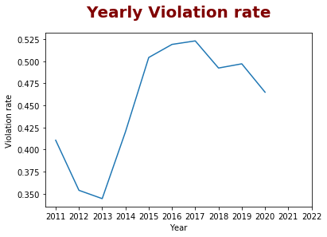

```python
#plot the yearly graph
import matplotlib.pyplot as plt
plt.xlabel('Year')
plt.ylabel('Violation rate')
plt.title('Yearly Violation rate', fontdict={'fontsize': 20, 'fontweight': 700, 'color': 'maroon'}, pad=20)
plt.plot(frequency)
plt.xticks(year)
```

```python
#calculate the frequencies
grouped3=df10.groupby(by='Month')["Violation_counts"].agg('count')
grouped4=dfr.groupby(by='Month')["Violation_counts"].agg('count')
frequency2=grouped3/grouped4
frequency2
```

```
Month
1     0.469199
2     0.456460
3     0.484681
4     0.467643
5     0.504359
6     0.501281
7     0.499224
8     0.493989
9     0.467655
10    0.466667
11    0.471322
12    0.457597
Name: Violation_counts, dtype: float64
```

```python
month=pd.Series(range(1,13,1))
```

```
 <a list of 12 Text xticklabel objects>)
```

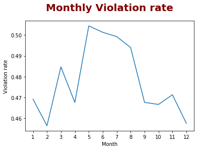

```python
#plot the monthly graph
import matplotlib.pyplot as plt
plt.xlabel('Month')
plt.ylabel('Violation rate')
plt.title('Monthly Violation rate', fontdict={'fontsize': 20, 'fontweight': 700, 'color': 'maroon'}, pad=20)
plt.plot(frequency2)
plt.xticks(month)
```

Are inspections getting harder or easier over time? Is there a particular month where more restaurants pass?

Create a map that shows all of the restaurants. Color the restaurants with at least one violation in red.

```python
#extract longitude and latitude for all restaurants
dfr['LL']=dfr['Location'].str.extract('(\d+.\d+ \d+.\d+)')
dfr['LL'].head()
```

```
0    76.838165 39.095491
1                    NaN
3    76.729269 38.983881
5    76.910024 38.997563
6    76.822919 38.895049
Name: LL, dtype: object
```

```python
dfr['Longitude']=dfr['LL'].str.split(' ').str[0]
dfr['Longitude'].head()
```

```
0    76.838165
1          NaN
3    76.729269
5    76.910024
6    76.822919
Name: Longitude, dtype: object
```

```python
dfr['Latitude']=dfr['LL'].str.split(' ').str[1]
dfr['Latitude'].head()
```

```
0    39.095491
1          NaN
3    38.983881
5    38.997563
6    38.895049
Name: Latitude, dtype: object
```

```python
#extract longitude and latitude for restaurant inspections that have at least one violation
df10['LL']=df10['Location'].str.extract('(\d+.\d+ \d+.\d+)')
df10['Longitude']=df10['LL'].str.split(' ').str[0]
df10['Latitude']=df10['LL'].str.split(' ').str[1]
```

```python
# Enter your OWN mapbox token here!
mapbox_access_token =  'pk.eyJ1IjoiZXZhemhvdTExNyIsImEiOiJjazlnNjFkbXkwY284M2tvMnN1NWNreG5xIn0.q3Q1pKC8fZcAPrjaoGNyyg'
```

```python
#create a map
import plotly.graph_objects as go
fig = go.Figure()
fig.add_trace(go.Scattermapbox(
        text = dfr['Name'],
        lon = dfr['Longitude'],
        lat = dfr['Latitude'],
        hoverinfo='text',
        mode = 'markers',
        marker = dict(
                    color = 'green',
                    symbol = 'circle',
                    size=8
                )
    ))

fig.add_trace(go.Scattermapbox(
        lon = df10['Longitude'],
        lat = df10['Latitude'],
        mode = 'markers',
        marker = dict(
                    color = 'red',
                    size=8
                ),
        hoverinfo='none'
    ))

fig.update_layout(
        title = 'Restaurants',
        mapbox=go.layout.Mapbox(
            accesstoken=mapbox_access_token,
            zoom=1
        )
    )

fig.show()
```

[interactive chart not shown]

Are there particular areas with more violations? ?

```python
df10.groupby(by=['City'])['Violation_counts'].agg('sum').sort_values(ascending=False).head()
```

```
City
LAUREL             1139
HYATTSVILLE        1133
CAPITOL HEIGHTS    1109
BOWIE              1066
COLLEGE PARK       1062
Name: Violation_counts, dtype: int64
```

We can see LAUREL,HYATTSVILLE,CAPITOL HEIGHTS,BOWIE and COLLEGE PARK have more more violations.

```python
dfcity=df10[(df10['City']=='LAUREL')|(df10['City']=='HYATTSVILLE')|(df10['City']=='CAPITOL HEIGHTS')|(df10['City']=='BOWIE ')|(df10['City']==' COLLEGE PARK ')]
dfcity.head()
```

|  | Establishment_id | Name | Category | Inspection_date | Inspection_results | City | State | Zip | Address_line_1 | Address_line_2 | ... | Zip Codes | Restaurant_or_not | Year | Month | Month_Year | Violation_counts | Compliance_or_not | LL | Longitude | Latitude |
| --- | --- | --- | --- | --- | --- | --- | --- | --- | --- | --- | --- | --- | --- | --- | --- | --- | --- | --- | --- | --- | --- |
| 0 | 8176 | LAUREL DUTCH MARKET - SAMMIE'S PRODUCE | Carry-out | 09/05/2019 12:00:00 AM | Critical Violations observed | LAUREL | MD | 20707.0 | 9701 FORT MEADE RD | ------ | ... | 15996.0 | 1 | 2019 | 9 | 2019-09 | 1 | 1 | 76.838165 39.095491 | 76.838165 | 39.095491 |
| 29 | 1149 | EL PATRON TAQUERIA | Full Service | 09/06/2019 12:00:00 AM | Non-Compliant - Violations Observed | LAUREL | MD | 20707.0 | 9700 FORT MEADE RD | ------ | ... | 15996.0 | 1 | 2019 | 9 | 2019-09 | 1 | 1 | 76.837675 39.095924 | 76.837675 | 39.095924 |
| 59 | 233 | CAMERON'S SEAFOOD RESTAURANT | Carry-out | 09/10/2019 12:00:00 AM | Critical Violations observed | CAPITOL HEIGHTS | MD | 20743.0 | 8807 CENTRAL AVE | A | ... | 15568.0 | 1 | 2019 | 9 | 2019-09 | 4 | 1 | 76.852767 38.890613 | 76.852767 | 38.890613 |
| 97 | 14044 | Jersey Mike's Subs | Fast Food | 09/06/2019 12:00:00 AM | Critical Violations observed | CAPITOL HEIGHTS | MD | 20743.0 | 9100 ALAKING CT | 110 | ... | 15568.0 | 1 | 2019 | 9 | 2019-09 | 1 | 1 | 76.849299 38.870078 | 76.849299 | 38.870078 |
| 125 | 894 | THE LITTLE CHICKADEE | Carry-out | 09/11/2019 12:00:00 AM | ------ | LAUREL | MD | 20707.0 | 643 MAIN ST | ------ | ... | 15996.0 | 1 | 2019 | 9 | 2019-09 | 1 | 1 | 76.853077 39.108221 | 76.853077 | 39.108221 |

5 rows × 39 columns

```python
#extract longitude and latitude for cities with more violations
dfcity['LL']=dfcity['Location'].str.extract('(\d+.\d+ \d+.\d+)')
dfcity['Longitude']=dfcity['LL'].str.split(' ').str[0]
dfcity['Latitude']=dfcity['LL'].str.split(' ').str[1]
```

```python
city_map_data = go.Scattermapbox(
        lon = dfcity['Longitude'],
        lat = dfcity['Latitude'],
        text = dfcity['Name'],
        hoverinfo='text',
        mode = 'markers',
        marker = dict(
                    color = 'orange',
                    symbol = 'circle',
                    opacity = .5
                )
)

city_map_layout = go.Layout(
        title = 'Cities with more violations',
        mapbox=go.layout.Mapbox(
            accesstoken=mapbox_access_token,
            zoom=1
        )
    )

city_map = go.Figure(data=city_map_data, layout=city_map_layout)
city_map.show()
```

[interactive chart not shown]

From the map we can see restaurants which has more violations are located at two main areas, And in these two areas restaurants are very close to each other.